# Multi Variable Visualization

4 July 2014

## Multi Variable Visualization

- **Multiple Aesthetics**
- Facetting
- Matrix View
- Parallel Coordinates
- Interaction - Linking / Brushing
- 3d Static
- 3d Interactive

## Multiple Aesthetics

Showing more than two variables using aesthetics

- Color
- Shape
- Size

## Fuel Economy Dataset

```r
library(ggplot2)
?mpg
head(mpg)
```

```
##   manufacturer model displ year cyl      trans drv cty hwy fl   class
## 1         audi    a4   1.8 1999   4   auto(l5)   f  18  29  p compact
## 2         audi    a4   1.8 1999   4 manual(m5)   f  21  29  p compact
## 3         audi    a4   2.0 2008   4 manual(m6)   f  20  31  p compact
## 4         audi    a4   2.0 2008   4   auto(av)   f  21  30  p compact
## 5         audi    a4   2.8 1999   6   auto(l5)   f  16  26  p compact
## 6         audi    a4   2.8 1999   6 manual(m5)   f  18  26  p compact
```

## Fuel Economy Dataset

```r
str(mpg)
```

```
## 'data.frame':    234 obs. of  11 variables:
##  $ manufacturer: Factor w/ 15 levels "audi","chevrolet",..: 1 1 1 1 1 1 1 1 1 1 ...
##  $ model       : Factor w/ 38 levels "4runner 4wd",..: 2 2 2 2 2 2 2 3 3 3 ...
##  $ displ       : num  1.8 1.8 2 2 2.8 2.8 3.1 1.8 1.8 2 ...
##  $ year        : int  1999 1999 2008 2008 1999 1999 2008 1999 1999 2008 ...
##  $ cyl         : int  4 4 4 4 6 6 6 4 4 4 ...
##  $ trans       : Factor w/ 10 levels "auto(av)","auto(l3)",..: 4 9 10 1 4 9 1 9 4 10 ...
##  $ drv         : Factor w/ 3 levels "4","f","r": 2 2 2 2 2 2 2 1 1 1 ...
##  $ cty         : int  18 21 20 21 16 18 18 18 16 20 ...
##  $ hwy         : int  29 29 31 30 26 26 27 26 25 28 ...
##  $ fl          : Factor w/ 5 levels "c","d","e","p",..: 4 4 4 4 4 4 4 4 4 4 ...
##  $ class       : Factor w/ 7 levels "2seater","compact",..: 2 2 2 2 2 2 2 2 2 2 ...
```

## Scatterplot - Categorical vs. Continuous

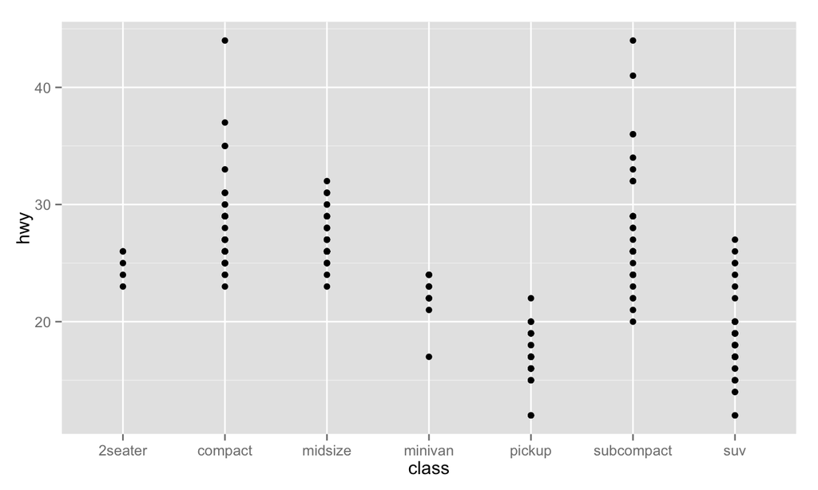

```r
ggplot(mpg, aes(class, hwy)) + geom_point()
```

## Scatterplot - Reorder

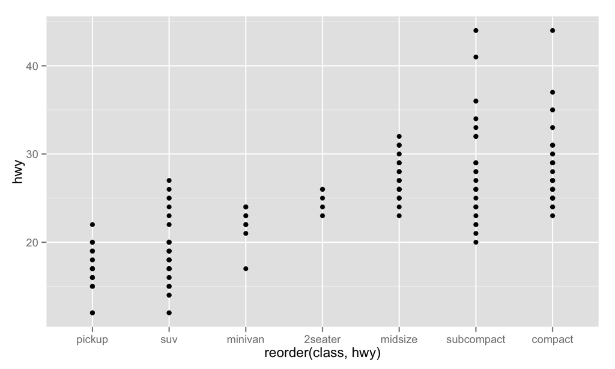

```r
ggplot(mpg, aes(reorder(class, hwy), hwy)) + geom_point()
```

## Scatterplot - Reorder based on max

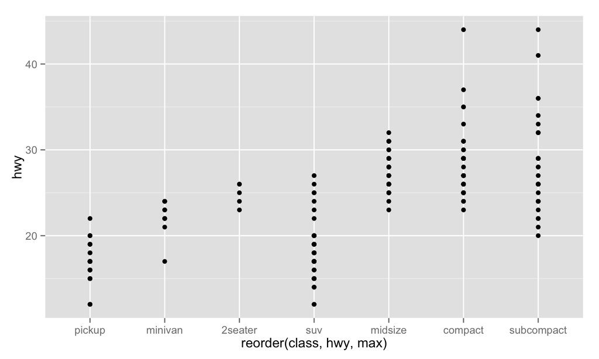

```r
ggplot(mpg, aes(reorder(class, hwy, max), hwy)) + geom_point()
```

## Scatterplot - Add a smooth curve

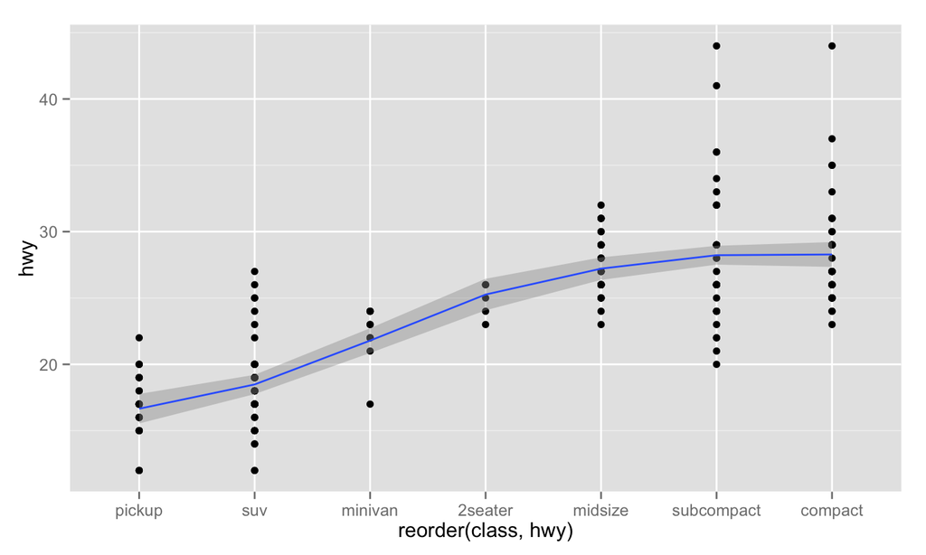

```r
ggplot(mpg, aes(reorder(class, hwy), hwy)) + geom_point() +
  geom_smooth(aes(group = 1), method = loess)
```

## Basic Scatterplot - Continuous vs Continuous

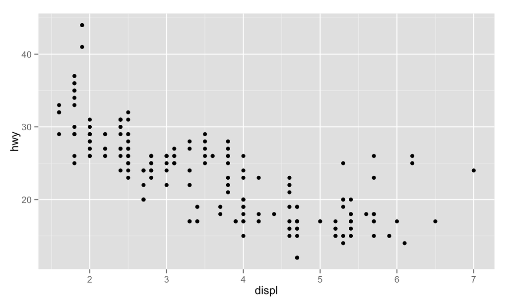

```r
ggplot(mpg, aes(displ, hwy)) + geom_point()
```

## Add variable: Color - Discrete

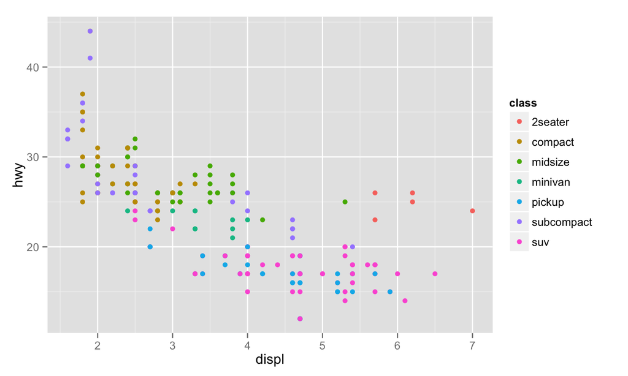

```r
ggplot(mpg, aes(displ, hwy, colour = class)) + geom_point()
```

## Add variable: Color - Continuous

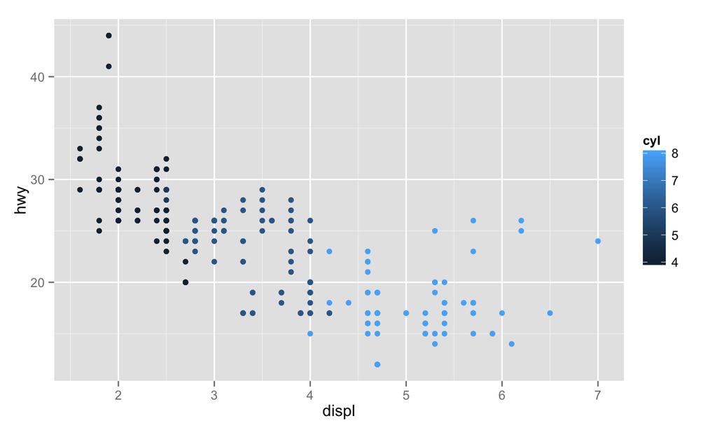

```r
ggplot(mpg, aes(displ, hwy, colour = cyl)) + geom_point()
```

## Add variable: Size - Discrete

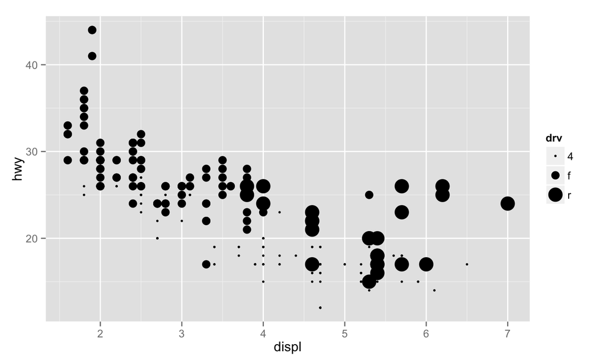

```r
ggplot(mpg, aes(displ, hwy, size = drv)) + geom_point()
```

## Add variable: Size - Continuous

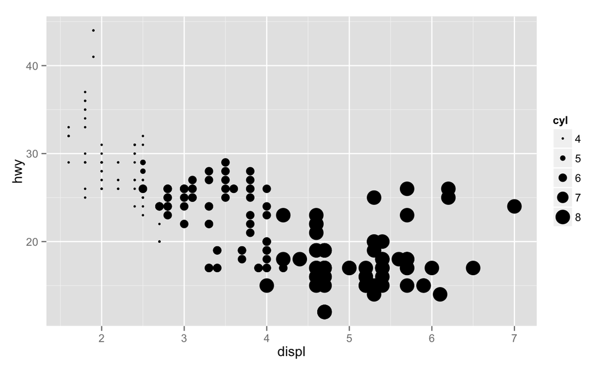

```r
ggplot(mpg, aes(displ, hwy, size = cyl)) + geom_point()
```

## Add variable: Shape - Discrete

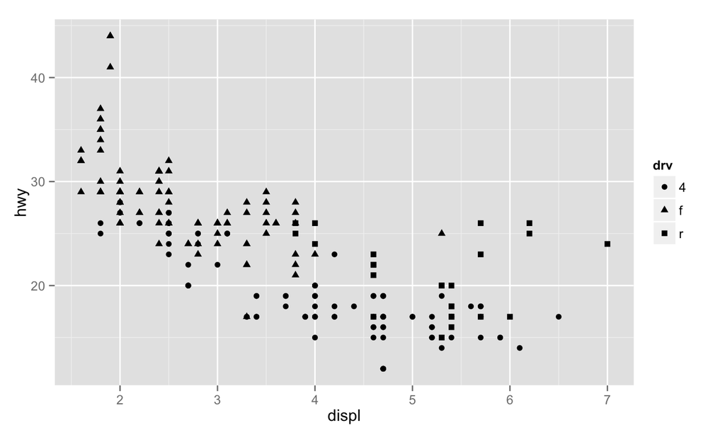

```r
ggplot(mpg, aes(displ, hwy, shape = drv)) + geom_point()
```

## Add variable: Shape + Color

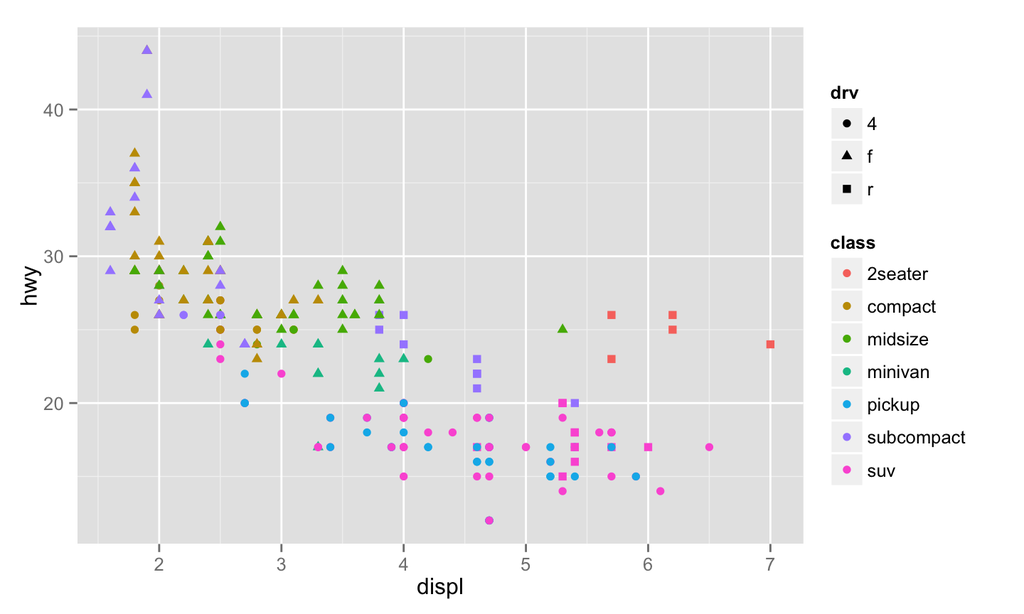

```r
ggplot(mpg, aes(displ, hwy, color = class, shape = drv)) + geom_point()
```

## Multi Variable Visualization

- Multiple Aesthetics
- **Facetting**
- Matrix View
- Parallel Coordinates
- Interaction - Linking / Brushing
- 3d Static
- 3d Interactive

## Facetting - Two options

**facet_grid**

2d grid, rows ~ cols, . for no split

**facet_wrap**

1d ribbon wrapped into 2d

## Facetting - Wrap

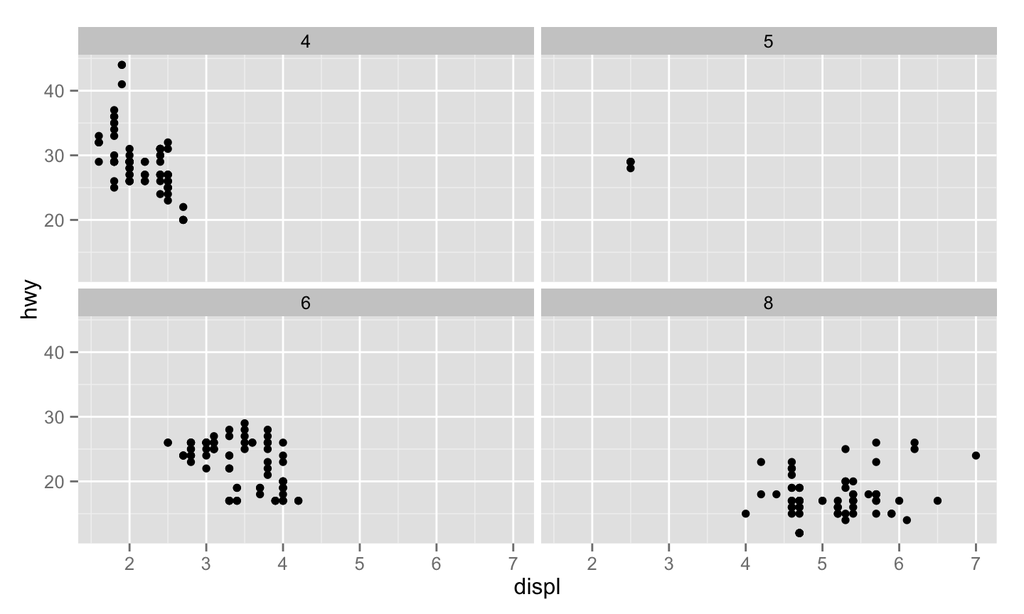

```r
ggplot(mpg, aes(displ, hwy)) + geom_point() + facet_wrap(~ cyl)
```

## Facetting - Grid - Row

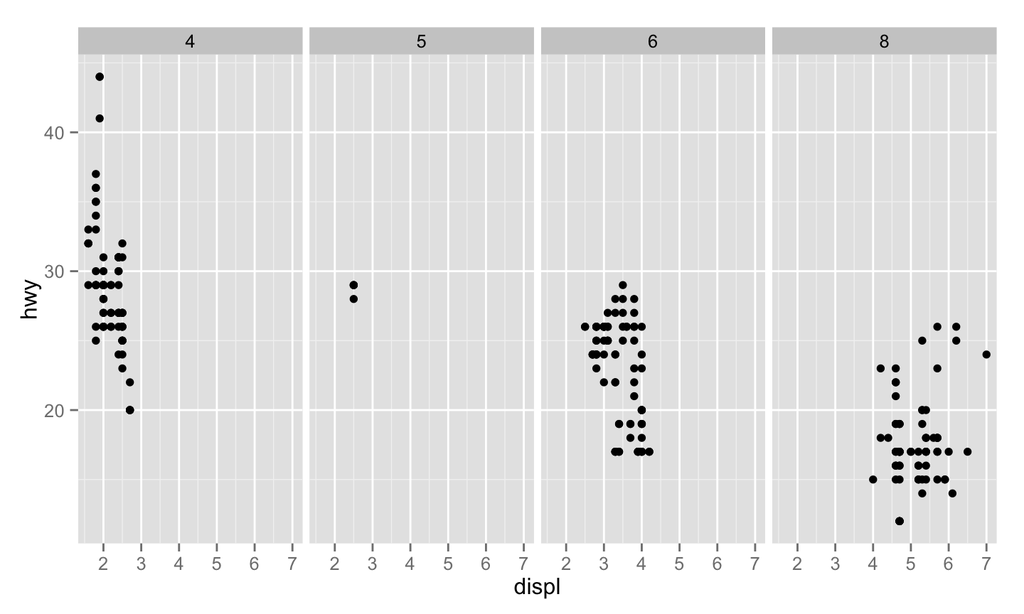

```r
ggplot(mpg, aes(displ, hwy)) + geom_point() + facet_grid(. ~ cyl)
```

## Facetting - Grid - Column

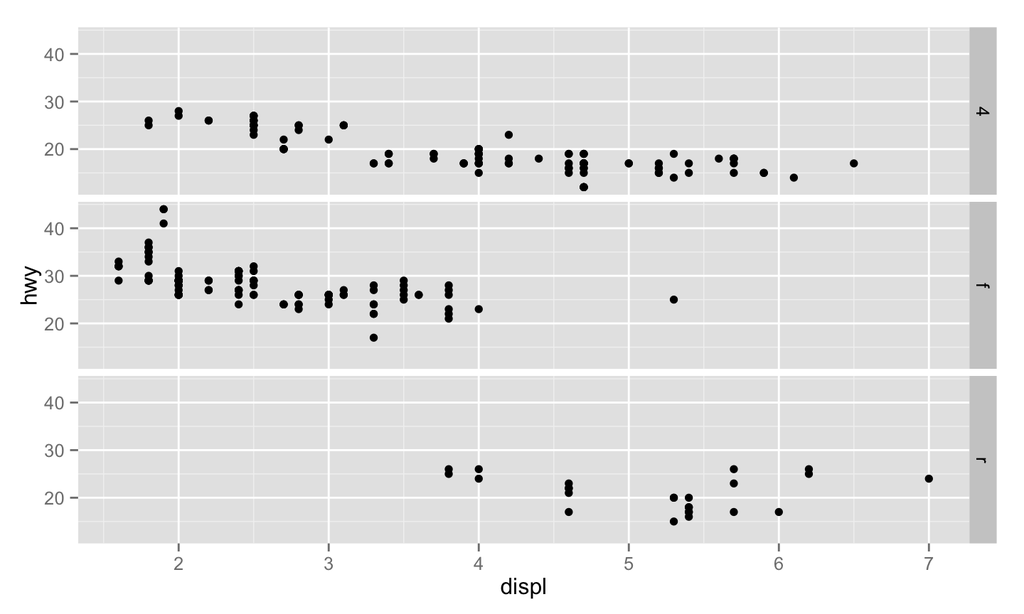

```r
ggplot(mpg, aes(displ, hwy)) + geom_point() + facet_grid(drv ~ .)
```

## Facetting - Grid - Row & Column

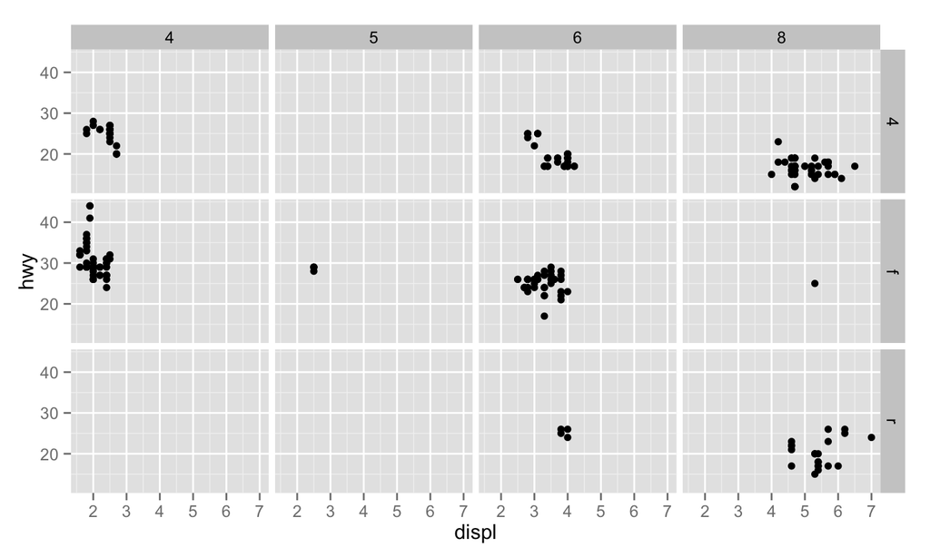

```r
ggplot(mpg, aes(displ, hwy)) + geom_point() + facet_grid(drv ~ cyl)
```

## Multi Variable Visualization

- Multiple Aesthetics
- Facetting
- **Matrix View**
- Parallel Coordinates
- Interaction - Linking / Brushing
- 3d Static
- 3d Interactive

## Using GGally

```r
library(GGally)
mpg_select <- subset(mpg, select = c(displ, hwy, drv))
```

## Matrix Views

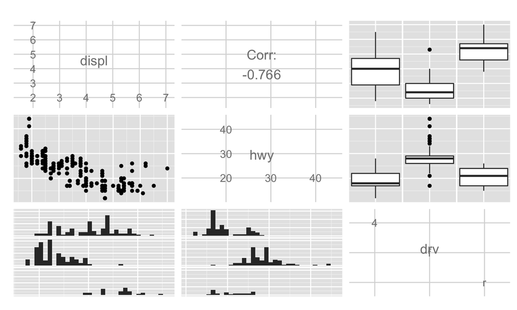

```r
ggpairs(mpg_select)
```

## Matrix Views - Diagonal

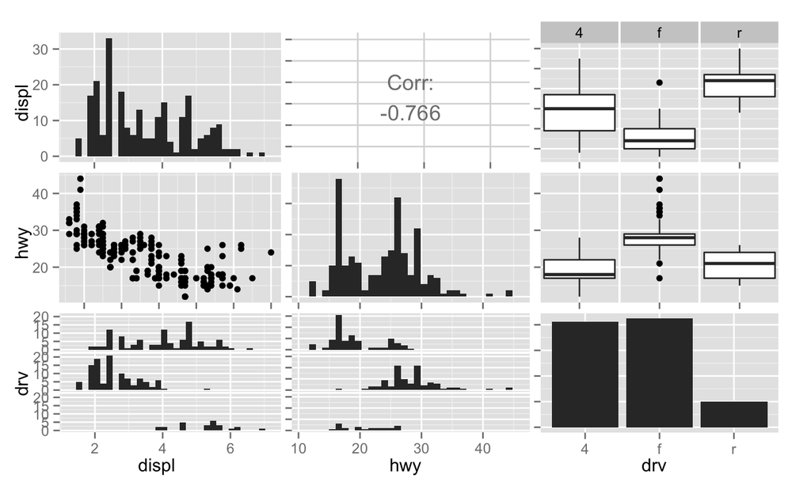

```r
ggpairs(mpg_select, diag = list(continuous = "bar", discrete = "bar"),
        axisLabels = 'show')
```

## Matrix Views - Upper & Lower

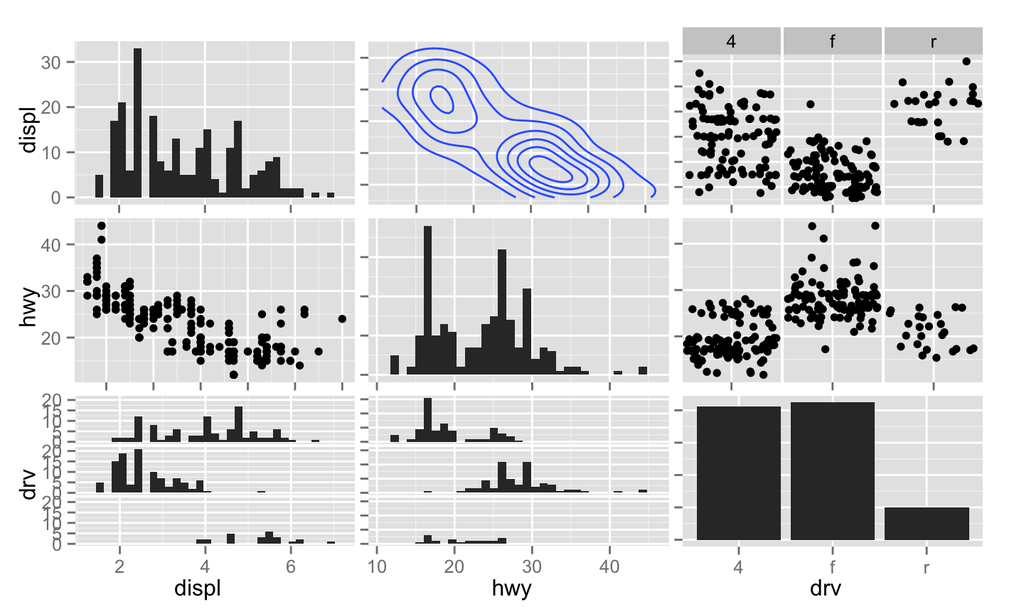

```r
ggpairs(mpg_select, diag = list(continuous = "bar", discrete = "bar"),
        upper = list(continuous = "density", combo = "dot"),
        axisLabels = 'show')
```

## Multi Variable Visualization

- Multiple Aesthetics
- Facetting
- Matrix View
- **Parallel Coordinates**
- Interaction - Linking / Brushing
- 3d Static
- 3d Interactive

## Parallel Coordinates

- Plotting more than three variables on parallel lines
- See the patterns
- Order of the variables matter
- Really effective in an interactive setup

## Parallel Coordinates

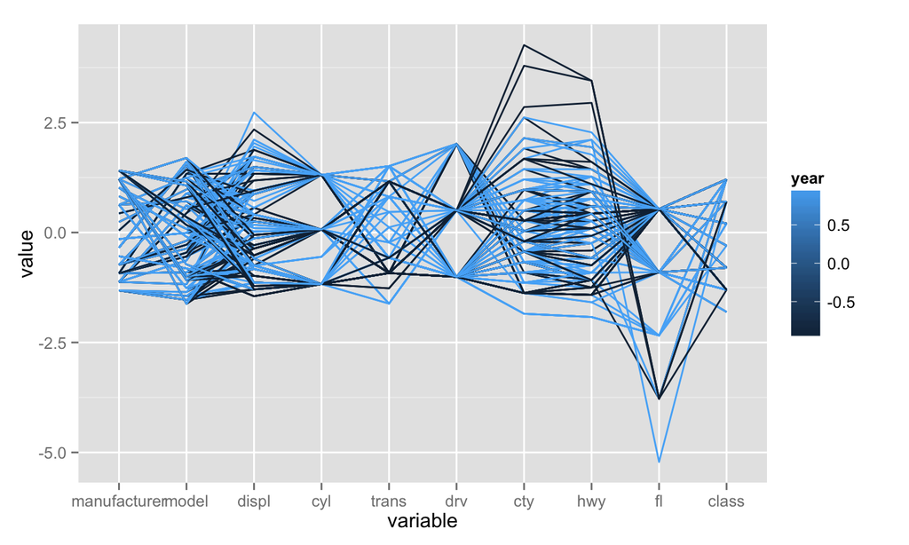

```r
ggparcoord(mpg, column = c(1:11), groupColumn = 4)
```

## Multi Variable Visualization

- Multiple Aesthetics
- Facetting
- Matrix View
- Parallel Coordinates
- **Interaction - Linking / Brushing**
- 3d Static
- 3d Interactive

## Download csv and load in Mondrian

```r
write.csv(mpg, file = "mpg.csv",
            quote = FALSE,
            row.names = FALSE)
```

## Multi Variable Visualization

- Multiple Aesthetics
- Facetting
- Matrix View
- Parallel Coordinates
- Interaction - Linking / Brushing
- **3d Static**
- 3d Interactive

## scatterplot3d

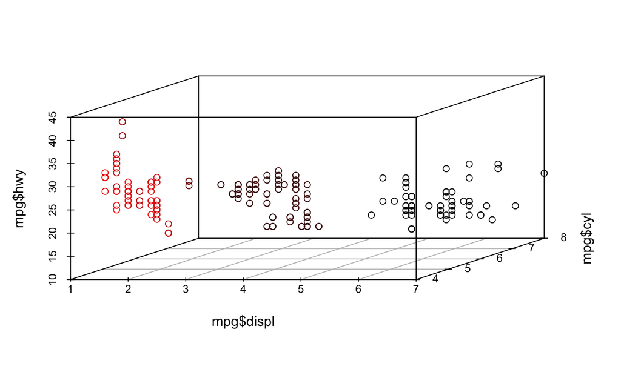

```r
library(scatterplot3d)
scatterplot3d(mpg$displ, mpg$cyl, mpg$hwy,
              highlight.3d = TRUE)
```

## Multi Variable Visualization

- Multiple Aesthetics
- Facetting
- Matrix View
- Parallel Coordinates
- Interaction - Linking / Brushing
- 3d Static
- **3d Interactive**

## rgl - 3d plot

```r
library(rgl)
# plot3d(mpg$displ, mpg$hwy, mpg$cyl, type = "p", col = "red")
```

## GGobi

- Similiar to Mondrian but with 3D and Tours
- Draws dotplots and scatterplots, barcharts, spineplots and histograms, parallel coordinate plots, scatterplot matrices
- Links data points and lines between plots using persistent or transient brushing, and identification
- Allows pan and zoom
- Rotates data in 3D
- Tour high-dimensional data using sequences of 1D, 2D and 2x1D projections augmented by manual control and automatic projection pursuit guidance
- Acts as a high-dimensional drawing tool, by adding, moving, and drawing lines between points.

## Contact

Amit Kapoor

Partner, narrativeVIZ Consulting

amit@narrativeviz.com

narrativeviz.com

You can find this presentation and more at:

narrativeviz.com/playbook